# ie360 hw2

2022-05-11

### Homework 2

The aim of this study is to forescast unleaded gasoline sale for every quarter of the year 2007 using time series regression models.

For this purpose, the data consisting of quarterly gasoline and diesel sales as well as some potential independent variables between 2000 and 2006 will be used.

## Reading and Manipulating Data

First, we start off by installing and packing the packages that will be needed. Then data is read and stored in a data table.

Then for readablity, columns are renamed.These are summarized as follows:

UGS: Unleaded gasoline sale in a given quarter, RNUV: An index indicating the rate of new unleaded gasoline using vehicles being added to the traffic in a quarter, PU: Average price (adjusted with an index) of a liter of unleaded gasoline in a quarter, PG: Average price (adjusted with an index) of a liter of diesel gasoline in a quarter, NUGV: Number of unleaded gasoline using vehicles in the traffic, NDGV: Number of diesel gasoline using vehicles in the traffic (per 1000 people), GNPA: Agriculture component of Gross National Product (adjusted with an index), GNPC: Commerce component of Gross National Product (adjusted with an index), GNPT: Grand total for GNP (agriculture, commerce and other components total).

Also, it the thousand seperators in excel vs R was inconsistent, therefore, necessary manipulations were done.

Furthermore, the quarter info is converted to a date data from character data to work with time series.

```r
setwd("C:/Users/dogad/Desktop/IE360")
require(data.table)
require(lubridate)
require(zoo)
require(ggplot2)
require(RcppRoll)
require(GGally)
require(forecast)
petroldata<-fread("IE360_Spring22_HW2_data.csv")
str(petroldata)
```

```
## Classes 'data.table' and 'data.frame':   32 obs. of  11 variables:
##  $ Quarter                             : chr  "2000_Q1" "2000_Q2" "2000_Q3" "2000_Q4" ...
##  $ Unleaded Gasoline Sale (UGS)        : chr  "1 128 971" "1 199 569" "1 370 167" "1 127 548" ...
##  $ RNUV                                : num  0.0146 0.0205 0.0207 0.0163 0.0071 0.0051 0.0041 0.0048 0.0012 0.0032 ...
##  $ # LPG Vehicles (NLPG)               : chr  "940 000" "941 000" "943 500" "948 000" ...
##  $ Price of Unleaded Gasoline (PU)     : num  469 459 440 402 412 ...
##  $ Price of Diesel Gasoline (PG)       : num  356 345 327 301 306 ...
##  $ # Unleaded Gasoline Vehicles (NUGV) : chr  "4 647 500" "4 742 876" "4 840 931" "4 919 685" ...
##  $ # of Diesel Gasoline Vehicles (NDGV): num  282 284 287 288 288 ...
##  $ GNP Agriculture                     : chr  "1 040 173" "1 760 460" "6 974 808" "3 267 125" ...
##  $ GNP Commerce                        : chr  "3 483 132" "4 525 451" "5 915 204" "4 929 778" ...
##  $ GNP Total                           : chr  "18 022 686" "21 797 130" "30 050 207" "24 480 153" ...
##  - attr(*, ".internal.selfref")=<externalptr>
```

```r
petroldata$`Unleaded Gasoline Sale (UGS)`=as.numeric(gsub(" ", "", petroldata$`Unleaded Gasoline Sale (UGS)`))
petroldata$`# LPG Vehicles (NLPG)`=as.numeric(gsub(" ", "",petroldata$`# LPG Vehicles (NLPG)` ))
petroldata$`# Unleaded Gasoline Vehicles (NUGV)`=as.numeric(gsub(" ", "", petroldata$`# Unleaded Gasoline Vehicles (NUGV)`))
petroldata$`GNP Agriculture`=as.numeric(gsub(" ", "", petroldata$`GNP Agriculture`))
petroldata$`GNP Commerce`=as.numeric(gsub(" ", "", petroldata$`GNP Commerce`))
petroldata$`GNP Total`=as.numeric(gsub(" ", "", petroldata$`GNP Total`))

petroldata$Quarter= as.Date(as.yearqtr(petroldata$Quarter,format="%Y_Q%q"))

str(petroldata)
```

```
## Classes 'data.table' and 'data.frame':   32 obs. of  11 variables:
##  $ Quarter                             : Date, format: "2000-01-01" "2000-04-01" ...
##  $ Unleaded Gasoline Sale (UGS)        : num  1128971 1199569 1370167 1127548 1033918 ...
##  $ RNUV                                : num  0.0146 0.0205 0.0207 0.0163 0.0071 0.0051 0.0041 0.0048 0.0012 0.0032 ...
##  $ # LPG Vehicles (NLPG)               : num  940000 941000 943500 948000 950000 ...
##  $ Price of Unleaded Gasoline (PU)     : num  469 459 440 402 412 ...
##  $ Price of Diesel Gasoline (PG)       : num  356 345 327 301 306 ...
##  $ # Unleaded Gasoline Vehicles (NUGV) : num  4647500 4742876 4840931 4919685 4954754 ...
##  $ # of Diesel Gasoline Vehicles (NDGV): num  282 284 287 288 288 ...
##  $ GNP Agriculture                     : num  1040173 1760460 6974808 3267125 1004528 ...
##  $ GNP Commerce                        : num  3483132 4525451 5915204 4929778 3418387 ...
##  $ GNP Total                           : num  18022686 21797130 30050207 24480153 15832648 ...
##  - attr(*, ".internal.selfref")=<externalptr>
```

```r
setnames(petroldata,old = c("Unleaded Gasoline Sale (UGS)"  ,"RNUV", "# LPG Vehicles (NLPG)"
                            ,"Price of Unleaded Gasoline (PU)"      ,"Price of Diesel Gasoline (PG)"
                            ,"# Unleaded Gasoline Vehicles (NUGV)"  ,"# of Diesel Gasoline Vehicles (NDGV)"
                            ,"GNP Agriculture"                      ,"GNP Commerce"
                            ,"GNP Total"        ),new= c("ugs","rnuv","nlpg","pu","pg","nugv","ndgv","gnpa","gnpc","gnpt"))

str(petroldata)
```

```
## Classes 'data.table' and 'data.frame':   32 obs. of  11 variables:
##  $ Quarter: Date, format: "2000-01-01" "2000-04-01" ...
##  $ ugs    : num  1128971 1199569 1370167 1127548 1033918 ...
##  $ rnuv   : num  0.0146 0.0205 0.0207 0.0163 0.0071 0.0051 0.0041 0.0048 0.0012 0.0032 ...
##  $ nlpg   : num  940000 941000 943500 948000 950000 ...
##  $ pu     : num  469 459 440 402 412 ...
##  $ pg     : num  356 345 327 301 306 ...
##  $ nugv   : num  4647500 4742876 4840931 4919685 4954754 ...
##  $ ndgv   : num  282 284 287 288 288 ...
##  $ gnpa   : num  1040173 1760460 6974808 3267125 1004528 ...
##  $ gnpc   : num  3483132 4525451 5915204 4929778 3418387 ...
##  $ gnpt   : num  18022686 21797130 30050207 24480153 15832648 ...
##  - attr(*, ".internal.selfref")=<externalptr>
```

## Data Visualizations

First, the output variable is plotted with respect to time.

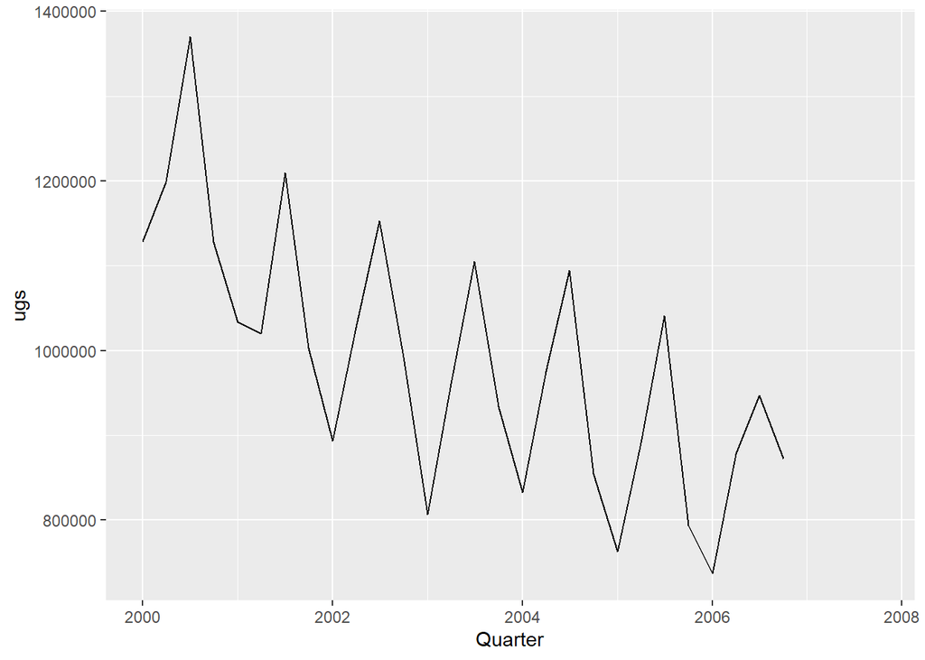

```r
ggpugs <- ggplot(data = petroldata,aes(x = Quarter,y =ugs))
ggpugs + geom_line(color ="black")
```

From visually observing the graph, data seems to follow a patern with a period of 4 quarters. Also there seems to be an overall downward trend.

Therefore, it would be logical to check if the series is stationary. Thus, Roling mean and rolling variance series are checked for a lag of 4.

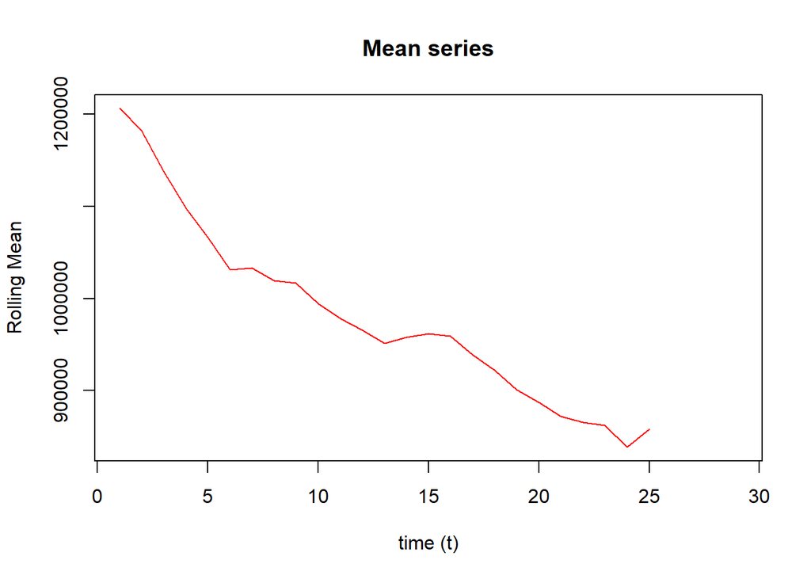

```r
mean_series=roll_mean(petroldata$ugs,4,align='left')
var_series=roll_var(petroldata$ugs,4,align='left') ######burda var time windiwouna kac diyecegimi bilmioyrum

plot(mean_series,
     type='l',col='red',
     xlab = "time (t)",
     ylab = "Rolling Mean",
     main = "Mean series")
```

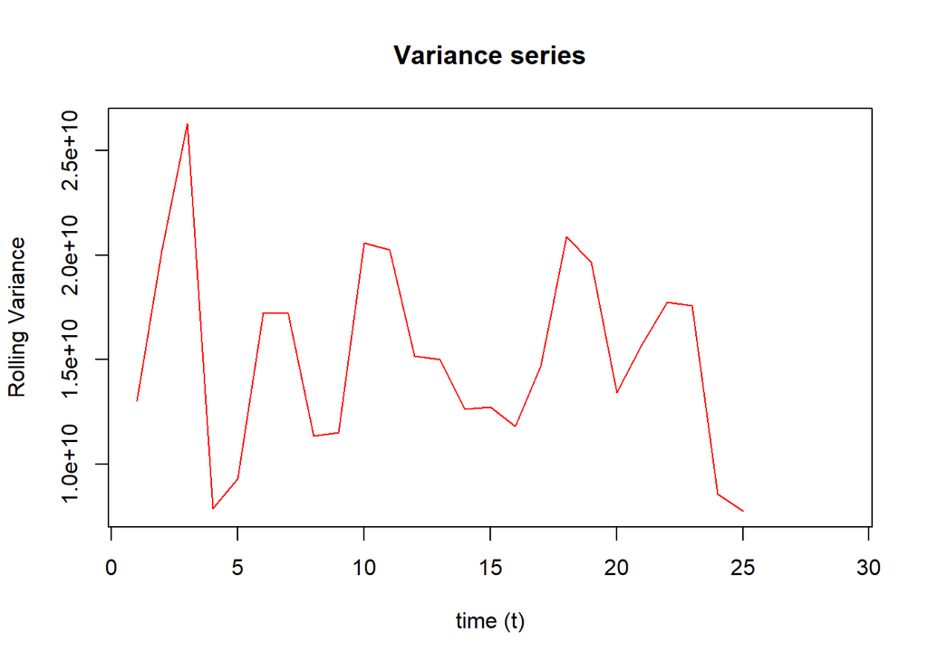

```r
plot(var_series,
     type='l',col='red',
     xlab = "time (t)",
     ylab = "Rolling Variance",
     main = "Variance series")
```

Mean series graph showed a downward trend. So we can say that the series is not actually stationary.

Variance series graph, however, showed almost random behaviour.

Then, autcorrelation function should be checked.

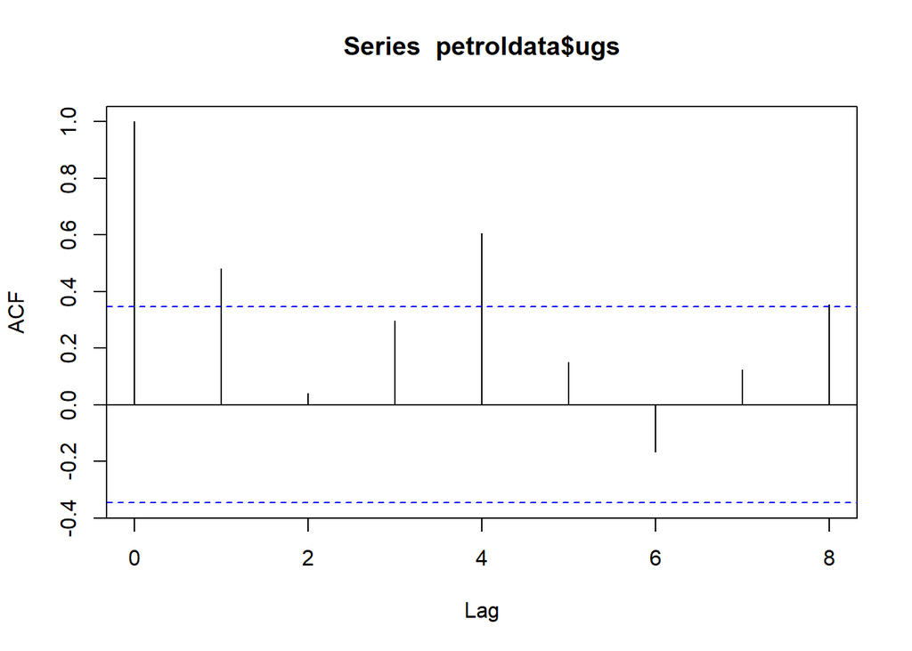

```r
acf(petroldata$ugs,lag.max=8,na.action = na.pass)
```

All these foundings show that data is in fact not stationary.